# Practical Machine Learning Project

Ben Wang

15/01/2017

## Introduction

In this project, we use the exercise data to find a classifier which identifies the manner in which the participants exercise.

## Load Data and Cleaning the Data

The training data for this project are available here: https://d396qusza40orc.cloudfront.net/predmachlearn/pml-training.csv

The test data are available here: https://d396qusza40orc.cloudfront.net/predmachlearn/pml-testing.csv

We load the training and testing data. We also remove the bad data points, e.g. NA, DIV/0 etc.

```r
#load data
raw_data <- read.csv("./data/pml-training.csv",
                     sep = ",",
                     na.strings = c("NA","#DIV/0!",""))
preTesting <- read.csv("./data/pml-testing.csv",
                       sep = ",",
                       na.strings = c("NA","#DIV/0!",""))

features <- names(preTesting[,colSums(is.na(preTesting)) == 0])[8:59]

# Only use features used in testing cases.
raw_data <- raw_data[,c(features,"classe")]
preTesting <- preTesting[,c(features,"problem_id")]

dim(raw_data);
```

```
## [1] 19622    53
```

```r
dim(preTesting);
```

```
## [1] 20 53
```

## Create Validation Dataset

Here, we split the data pml-training into training data (60%) and validation data (40%). The classifier trainied based on training data will be checked by using validation data. This shouldn’t be confused with pml-testing dataset.

```r
# Split raw training into training and validating
inTrain = createDataPartition(raw_data$classe, p = 0.6)[[1]]
preTraining = raw_data[inTrain,]
preValidating = raw_data[-inTrain,]
```

## Explanatory Data Analysis

Two EDA charts are plotted to explore the data.

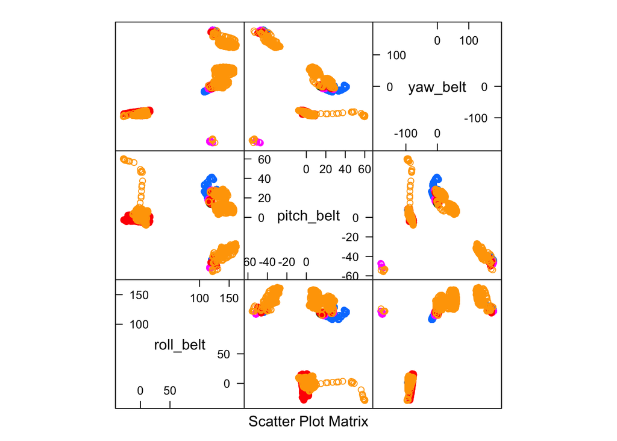

```r
featurePlot(x = preTraining[,c("roll_belt", "pitch_belt", "yaw_belt")],
            y = preTraining$classe,
            plot = "pairs")
```

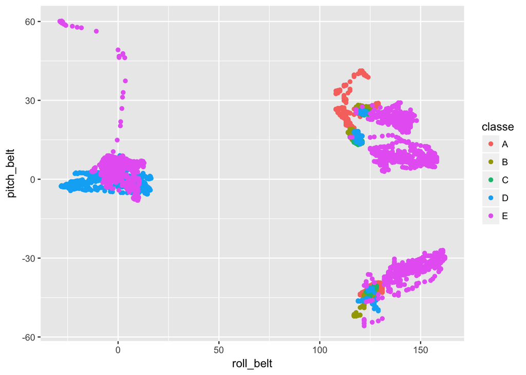

```r
qplot(roll_belt, pitch_belt, col = classe, data=preTraining)
```

## Train the Classifier

Since the number of labels are 5, the linear classification model would be slow. Thus, I start with nonliner model - **randomForest** directly.

```r
modRF <- randomForest(classe~., data=preTraining, method = "class")
predRF <- predict(modRF, preValidating, method = "class")
```

Below are the summary of performance of classifier on the validation data set.

```r
confusionMatrix(preValidating$classe, predRF)
```

```
## Confusion Matrix and Statistics
##
##           Reference
## Prediction    A    B    C    D    E
##          A 2224    6    1    0    1
##          B   11 1501    6    0    0
##          C    0    8 1360    0    0
##          D    0    0   24 1262    0
##          E    0    0    0    4 1438
##
## Overall Statistics
##
##                Accuracy : 0.9922
##                  95% CI : (0.99, 0.994)
##     No Information Rate : 0.2849
##     P-Value [Acc > NIR] : < 2.2e-16
##
##                   Kappa : 0.9902
##  Mcnemar's Test P-Value : NA
##
## Statistics by Class:
##
##                      Class: A Class: B Class: C Class: D Class: E
## Sensitivity            0.9951   0.9908   0.9777   0.9968   0.9993
## Specificity            0.9986   0.9973   0.9988   0.9964   0.9994
## Pos Pred Value         0.9964   0.9888   0.9942   0.9813   0.9972
## Neg Pred Value         0.9980   0.9978   0.9952   0.9994   0.9998
## Prevalence             0.2849   0.1931   0.1773   0.1614   0.1834
## Detection Rate         0.2835   0.1913   0.1733   0.1608   0.1833
## Detection Prevalence   0.2845   0.1935   0.1744   0.1639   0.1838
## Balanced Accuracy      0.9968   0.9940   0.9882   0.9966   0.9993
```

The accuracy is very high. Thus, we proceed to apply the prediction model on testing data.

## Prediction

Below are the prediction of testing dataset.

```r
predRF_test <- predict(modRF, preTesting, method = "class")
print(predRF_test)
```

```
##  1  2  3  4  5  6  7  8  9 10 11 12 13 14 15 16 17 18 19 20
##  B  A  B  A  A  E  D  B  A  A  B  C  B  A  E  E  A  B  B  B
## Levels: A B C D E
```